# thesis_2

Yu He

2023-04-04

# load libraries

```r
library(tidyverse)
library(haven)
library(caret)
```

```r
library(cluster)
library(nnet)
library(broom)
# library(pROC)
library(rpart.plot)
library(randomForest)
```

Variable list:

Demographic Factors: a. Age b. Sex c. Grade d. Race (race4)

Anthropometric Factors: a. Height - remove b. BMI c. BMI Percentile - removed d. Obesity Indicator (qnobese) - remove

Sexual Factors: a. Sexual Identity (sexed) - remove b. Birth Control Use (qnothhpl) c. Sexual Orientation (Q66) - remove

Food Allergy: a. Food Allergy (Qfoodallergy) - remove

Unintentional Injuries and Violence: a. Physical fights (Q17) b. Forced sexual activities (Q20) - remove c. Dating-related forced sexual activities (Q21) d. Bullying on school property (Q23) e. Suicidal thoughts (Q26)

Tobacco Use: a. Tried cigarette smoking (Q30)

Alcohol and Other Drug Use: a. Alcohol consumption (Q41) b. Marijuana use (Q47) c. Prescription pain medicine misuse (Q49) d. Cocaine use (Q50) e. Heroin use (Q52) f. Methamphetamine use (Q53) g. Needle use for injecting illegal drugs (Q56) - remove

Risky Sexual Behavior: a. Sexual intercourse (Q58) - remove b. Number of sexual partners (Q61) - remove c. Condom use (Q63) d. Sexual contact with different genders (Q65)

Cognitive and Health Factors: a. HIV testing (Q84) - remove b. Asthma diagnosis (Q87) c. School grades (Q89)

Outcome Variable: a. STI testing other than HIV (Q85)

# to do list: 1, remove the variabe with 0 level like age. 2. make q50, q52, and q53 into 2 level factors?. 3 remove q84?. 4. check difference between postreample and compare_resample function

# Step 1, data proparing

## data import and process, save the processed sas7dbat data into csv file to improve R runnig time. Only run one time.

```r
# set path
#setwd("~/Desktop/CU Spring 2023/master thesis II2/CU_2023_yu")

# load state data a_m
#df_a_m = read_sas("./data/sadc_2019_state_a_m.sas7bdat") %>%
#  janitor::clean_names() %>%
#  select(sitename, year, age, sex, grade, race4, bmi, qnothhpl, q85,
#         q17, q21, q23, q26, q30, q41, q47, q49, q50, q52, q53, q63, q65, q87, q89
#         )

# save the data as a CSV file
# write.csv(df_a_m, "./data/df_a_m.csv", row.names = FALSE)

# load state data n_z
#df_n_z = read_sas("./data/sadc_2019_state_n_z.sas7bdat") %>%
#  janitor::clean_names() %>%
#  select(sitename, year, age, sex, grade, race4, bmi, qnothhpl, q85,
#         q17, q21, q23, q26, q30, q41, q47, q49, q50, q52, q53, q63, q65, q87, q89)

# save the data as a CSV file
#write.csv(df_n_z, "./data/df_n_z.csv", row.names = FALSE)

# load school district data
#df_district = read_sas("./data/sadc_2019_district.sas7bdat") %>%
#  janitor::clean_names() %>%
#   select(sitename, year, age, sex, grade, race4, bmi, qnothhpl, q85,
#        q17, q21, q23, q26, q30, q41, q47, q49, q50, q52, q53, q63, q65, q87, q89)

# save the data as a CSV file
#write.csv(df_district, "./data/df_district.csv", row.names = FALSE)
```

## import the processed data

```r
# load the processed  state data
df_part1 = read_csv("./data/df_a_m.csv")
df_part2 = read_csv("./data/df_n_z.csv")
# merge two state dataset
df_f_project = bind_rows(df_part1, df_part2)

# load the district dataset
df_district = read_csv("./data/df_district.csv")
```

## data cleaning

```r
# the state data
df_fit_state <-
  df_f_project %>%
  filter(year == 2019) %>%
  mutate(
  across(c("sex", "age", "grade", "race4", "qnothhpl"), as.factor),
  year = as.character(year)
  ) %>%
  mutate_at(vars(starts_with("q")), as.factor) %>%
  filter(q85 %in% c(1, 2, 3)) %>%
  na.omit()

# the school distrcit data
df_fit_district <-
  df_district %>%
  filter(year == 2019) %>%
    mutate(
  across(c("sex", "age", "grade", "race4", "qnothhpl"), as.factor),
  year = as.character(year)
  ) %>%
  mutate_at(vars(starts_with("q")), as.factor) %>%
  filter(q85 %in% c(1, 2, 3)) %>%
  na.omit()

df_fit_state %>%
  group_by(sitename) %>%
  summarize(
    n_obs = n()
  )
```

```
## # A tibble: 12 × 2
##    sitename            n_obs
##    <chr>               <int>
##  1 Alabama (AL)          308
##  2 Arkansas (AR)         304
##  3 Illinois (IL)         398
##  4 Iowa (IA)             235
##  5 Kentucky (KY)         313
##  6 Michigan (MI)         582
##  7 Mississippi (MS)      265
##  8 Nebraska (NE)         201
##  9 Oklahoma (OK)         348
## 10 Pennsylvania (PA)     440
## 11 South Carolina (SC)   126
## 12 West Virginia (WV)    284
```

```r
df_fit_district %>%
  group_by(sitename) %>%
  summarize(
    n_obs = n()
  )
```

```
## # A tibble: 15 × 2
##    sitename                     n_obs
##    <chr>                        <int>
##  1 Broward County, FL (FT)        168
##  2 Chicago, IL (CH)               157
##  3 Eaton Consortium, MI (EA)      129
##  4 Fort Worth, TX (FW)            237
##  5 Genesee Consortium, MI (GE)    166
##  6 Hillsborough County, FL (HL)   248
##  7 Los Angeles, CA (LO)           109
##  8 Newark, NJ (NW)                142
##  9 Orange County, FL (OL)         123
## 10 Palm Beach County, FL (PB)     305
## 11 Pasco County, FL (PS)          200
## 12 Philadelphia, PA (PH)          172
## 13 Portland, OR (PO)              213
## 14 San Francisco, CA (SF)         203
## 15 Shelby County, TN (ST)         160
```

```r
summary(df_fit_district)
```

```
##    sitename             year           age     sex      grade    race4
##  Length:2732        Length:2732        1:  0   1:1485   1: 276   1: 818
##  Class :character   Class :character   2:  0   2:1247   2: 610   2: 581
##  Mode  :character   Mode  :character   3:111            3: 825   3:1036
##                                        4:421            4:1021   4: 297
##                                        5:730
##                                        6:946
##                                        7:524
##       bmi        qnothhpl q85           q17       q21      q23      q26
##  Min.   :13.58   1: 735   1: 715   1      :1912   1: 240   1: 414   1: 651
##  1st Qu.:20.38   2:1997   2:1849   2      : 345   2:2299   2:2318   2:2081
##  Median :22.49            3: 168   3      : 296   3:  91
##  Mean   :23.64                     4      :  89   4:  55
##  3rd Qu.:25.72                     8      :  39   5:  17
##  Max.   :58.89                     5      :  28   6:  30
##                                    (Other):  23
##  q30      q41      q47      q49      q50      q52      q53      q63
##  1: 779   1:1535   1:1577   1:2197   1:2579   1:2703   1:2690   1:   0
##  2:1953   2: 593   2: 374   2: 230   2:  81   2:  12   2:  20   2:1512
##           3: 340   3: 293   3: 136   3:  48   3:   3   3:   5   3:1220
##           4: 154   4: 162   4:  77   4:   8   4:   6   4:   1
##           5:  83   5: 144   5:  30   5:   6   5:   1   5:   7
##           6:  15   6: 182   6:  62   6:  10   6:   7   6:   9
##           7:  12
##  q65      q87      q89
##  1:   0   1: 686   1: 874
##  2:1237   2:1940   2:1066
##  3:1226   3: 106   3: 520
##  4: 269            4: 104
##                    5:  50
##                    6:  14
##                    7: 104
```

```r
summary(df_fit_state)
```

```
##    sitename             year           age      sex      grade    race4
##  Length:3804        Length:3804        1:   0   1:2028   1: 501   1:2396
##  Class :character   Class :character   2:   5   2:1776   2: 848   2: 546
##  Mode  :character   Mode  :character   3: 130            3:1222   3: 550
##                                        4: 616            4:1233   4: 312
##                                        5:1012
##                                        6:1254
##                                        7: 787
##       bmi        qnothhpl q85           q17       q21      q23      q26
##  Min.   :13.25   1:1364   1: 770   1      :2686   1: 303   1: 843   1: 948
##  1st Qu.:20.62   2:2440   2:2822   2      : 503   2:3238   2:2961   2:2856
##  Median :22.89            3: 212   3      : 391   3: 112
##  Mean   :24.20                     4      :  96   4:  90
##  3rd Qu.:26.51                     8      :  60   5:  29
##  Max.   :54.40                     5      :  38   6:  32
##                                    (Other):  30
##  q30      q41      q47      q49      q50      q52      q53      q63
##  1:1636   1:2031   1:2473   1:3038   1:3608   1:3760   1:3737   1:   0
##  2:2168   2: 873   2: 427   2: 323   2: 101   2:  22   2:  27   2:2001
##           3: 445   3: 313   3: 196   3:  44   3:   3   3:  10   3:1803
##           4: 248   4: 193   4:  97   4:  24   4:   2   4:   7
##           5: 150   5: 145   5:  69   5:   6   5:   2   5:   3
##           6:  30   6: 253   6:  81   6:  21   6:  15   6:  20
##           7:  27
##  q65      q87      q89
##  1:   0   1: 946   1:1430
##  2:1744   2:2724   2:1396
##  3:1765   3: 134   3: 668
##  4: 295            4: 147
##                    5:  50
##                    6:  12
##                    7: 101
```

## check variables with 0 variance levels and re-create new variables for un-balanced variables

```r
# the modification for school district data
levels(df_fit_district$age)
```

```
## [1] "1" "2" "3" "4" "5" "6" "7"
```

```r
levels(df_fit_district$q63)
```

```
## [1] "1" "2" "3"
```

```r
levels(df_fit_district$q65)
```

```
## [1] "1" "2" "3" "4"
```

```r
# drop the level with 0
df_fit_district = df_fit_district %>%
  # Remove levels from the factor column
  filter(!(age %in% c("1", "2"))) %>%
  filter(q63 != 1) %>%
  filter(q65 != 1) %>%
  mutate(
  # Remove the unused levels from the factor column
     age = factor(age),
     q63 = factor(q63),
     q65 = factor(q65),
  # cover q50, q52, q53 to two level variables
  # 1 = 1, and 2 = the rest of observations
     q50 = ifelse(q50 == 1, 1, 2),
     q50 = factor(q50),
     q52 = ifelse(q52 == 1, 1, 2),
     q52 = factor(q52),
     q53 = ifelse(q53 == 1, 1, 2),
     q53 = factor(q53)
  )

summary(df_fit_district)
```

```
##    sitename             year           age     sex      grade    race4
##  Length:2732        Length:2732        3:111   1:1485   1: 276   1: 818
##  Class :character   Class :character   4:421   2:1247   2: 610   2: 581
##  Mode  :character   Mode  :character   5:730            3: 825   3:1036
##                                        6:946            4:1021   4: 297
##                                        7:524
##
##
##       bmi        qnothhpl q85           q17       q21      q23      q26
##  Min.   :13.58   1: 735   1: 715   1      :1912   1: 240   1: 414   1: 651
##  1st Qu.:20.38   2:1997   2:1849   2      : 345   2:2299   2:2318   2:2081
##  Median :22.49            3: 168   3      : 296   3:  91
##  Mean   :23.64                     4      :  89   4:  55
##  3rd Qu.:25.72                     8      :  39   5:  17
##  Max.   :58.89                     5      :  28   6:  30
##                                    (Other):  23
##  q30      q41      q47      q49      q50      q52      q53      q63
##  1: 779   1:1535   1:1577   1:2197   1:2579   1:2703   1:2690   2:1512
##  2:1953   2: 593   2: 374   2: 230   2: 153   2:  29   2:  42   3:1220
##           3: 340   3: 293   3: 136
##           4: 154   4: 162   4:  77
##           5:  83   5: 144   5:  30
##           6:  15   6: 182   6:  62
##           7:  12
##  q65      q87      q89
##  2:1237   1: 686   1: 874
##  3:1226   2:1940   2:1066
##  4: 269   3: 106   3: 520
##                    4: 104
##                    5:  50
##                    6:  14
##                    7: 104
```

```r
# the modification for state data
levels(df_fit_state$age)
```

```
## [1] "1" "2" "3" "4" "5" "6" "7"
```

```r
levels(df_fit_state$q63)
```

```
## [1] "1" "2" "3"
```

```r
levels(df_fit_state$q65)
```

```
## [1] "1" "2" "3" "4"
```

```r
# drop the level with 0
df_fit_state = df_fit_state %>%
  # Remove levels from the factor column
  filter(age != 1) %>%
  filter(q63 != 1) %>%
  filter(q65 != 1) %>%
  mutate(
  # Remove the unused levels from the factor column
     age = factor(age),
     q63 = factor(q63),
     q65 = factor(q65),
  # cover q50, q52, q53 to two level variables
  # 1 = 1, and 2 = the rest of observations
     q50 = ifelse(q50 == 1, 1, 2),
     q50 = factor(q50),
     q52 = ifelse(q52 == 1, 1, 2),
     q52 = factor(q52),
     q53 = ifelse(q53 == 1, 1, 2),
     q53 = factor(q53)
  )

summary(df_fit_state)
```

```
##    sitename             year           age      sex      grade    race4
##  Length:3804        Length:3804        2:   5   1:2028   1: 501   1:2396
##  Class :character   Class :character   3: 130   2:1776   2: 848   2: 546
##  Mode  :character   Mode  :character   4: 616            3:1222   3: 550
##                                        5:1012            4:1233   4: 312
##                                        6:1254
##                                        7: 787
##
##       bmi        qnothhpl q85           q17       q21      q23      q26
##  Min.   :13.25   1:1364   1: 770   1      :2686   1: 303   1: 843   1: 948
##  1st Qu.:20.62   2:2440   2:2822   2      : 503   2:3238   2:2961   2:2856
##  Median :22.89            3: 212   3      : 391   3: 112
##  Mean   :24.20                     4      :  96   4:  90
##  3rd Qu.:26.51                     8      :  60   5:  29
##  Max.   :54.40                     5      :  38   6:  32
##                                    (Other):  30
##  q30      q41      q47      q49      q50      q52      q53      q63
##  1:1636   1:2031   1:2473   1:3038   1:3608   1:3760   1:3737   2:2001
##  2:2168   2: 873   2: 427   2: 323   2: 196   2:  44   2:  67   3:1803
##           3: 445   3: 313   3: 196
##           4: 248   4: 193   4:  97
##           5: 150   5: 145   5:  69
##           6:  30   6: 253   6:  81
##           7:  27
##  q65      q87      q89
##  2:1744   1: 946   1:1430
##  3:1765   2:2724   2:1396
##  4: 295   3: 134   3: 668
##                    4: 147
##                    5:  50
##                    6:  12
##                    7: 101
```

```r
# Check for missing values
missing_vals_1 <- is.na(df_fit_district)

# Count the number of missing values in each column
colSums(missing_vals_1)
```

```
## sitename     year      age      sex    grade    race4      bmi qnothhpl
##        0        0        0        0        0        0        0        0
##      q85      q17      q21      q23      q26      q30      q41      q47
##        0        0        0        0        0        0        0        0
##      q49      q50      q52      q53      q63      q65      q87      q89
##        0        0        0        0        0        0        0        0
```

```r
# Check for missing values
missing_vals_2 <- is.na(df_fit_state)

# Count the number of missing values in each column
colSums(missing_vals_2)
```

```
## sitename     year      age      sex    grade    race4      bmi qnothhpl
##        0        0        0        0        0        0        0        0
##      q85      q17      q21      q23      q26      q30      q41      q47
##        0        0        0        0        0        0        0        0
##      q49      q50      q52      q53      q63      q65      q87      q89
##        0        0        0        0        0        0        0        0
```

# Step 2, fit the multinominal logistic regression

## first try to fit on the whole data, ignore clustered by sitename for now.

```r
df_district_lr <- df_fit_district %>%
  select(-year)

# Fit the model using the cleaned dataset
model <- multinom(q85 ~ ., data = df_district_lr)
summary_model = summary(model)

# Get a tidy version of the model output
tidy_model <- tidy(model)

# Set the significance level
alpha <- 0.05

# Find significant variables based on the p-value
significant_vars <- tidy_model$p.value < alpha

# Print the significant variables
significant_results <- tidy_model[significant_vars, ]
print(significant_results)
```

```
## # A tibble: 29 × 6
##    y.level term                                 estim…¹ std.e…² stati…³  p.value
##    <chr>   <chr>                                  <dbl>   <dbl>   <dbl>    <dbl>
##  1 2       (Intercept)                            2.07    0.548    3.77 1.63e- 4
##  2 2       sitenameHillsborough County, FL (HL)   0.757   0.266    2.85 4.43e- 3
##  3 2       sitenamePhiladelphia, PA (PH)         -1.47    0.257   -5.73 1.00e- 8
##  4 2       age5                                  -0.802   0.395   -2.03 4.24e- 2
##  5 2       age6                                  -1.16    0.423   -2.74 6.23e- 3
##  6 2       age7                                  -1.22    0.450   -2.71 6.72e- 3
##  7 2       race42                                -0.736   0.165   -4.46 8.02e- 6
##  8 2       race43                                -0.444   0.140   -3.17 1.51e- 3
##  9 2       qnothhpl2                              0.790   0.115    6.87 6.44e-12
## 10 2       q173                                  -0.516   0.165   -3.13 1.75e- 3
## # … with 19 more rows, and abbreviated variable names ¹estimate, ²std.error,
## #   ³statistic
```

## fit multinominal logistic regression for every disctrict

```r
# Define a function to fit the multinom model for each site
fit_multinom_for_site_d <- function(site, data) {
  df_site <- data %>%
    filter(sitename == site) %>%
    select(-sitename) %>%
    select(-year)

  # Fit the model using the cleaned dataset
  model <- multinom(q85 ~ ., data = df_site)

  summary_model <- summary(model)
  tidy_model <- tidy(model)

  # Set the significance level
  alpha <- 0.05

  # Find significant variables based on the p-value
  significant_vars <- tidy_model$p.value < alpha

  # Print the significant variables
  significant_results <- tidy_model[significant_vars, ]
  return(list(site = site, significant_results = significant_results))
}

# Get the unique site names from the dataset
unique_sites_d <- unique(df_fit_district$sitename)

# Fit the multinom model for each site
models_by_site <- lapply(unique_sites_d, fit_multinom_for_site_d, data = df_fit_district)
# Display the results
print(models_by_site)
```

```
## [[1]]
## [[1]]$site
## [1] "Chicago, IL (CH)"
##
## [[1]]$significant_results
## # A tibble: 78 × 6
##    y.level term        estimate std.error statistic p.value
##    <chr>   <chr>          <dbl>     <dbl>     <dbl>   <dbl>
##  1 2       (Intercept)   104.    2.48e+ 0   4.18e 1  0
##  2 2       age4         -100.    1.21e+ 0  -8.28e 1  0
##  3 2       age5         -101.    9.09e- 1  -1.11e 2  0
##  4 2       age6         -102.    9.17e- 1  -1.11e 2  0
##  5 2       age7         -100.    1.18e+ 0  -8.51e 1  0
##  6 2       qnothhpl2       1.88  7.74e- 1   2.43e 0  0.0151
##  7 <NA>    <NA>           NA    NA         NA       NA
##  8 2       q176          397.    5.76e-15   6.89e16  0
##  9 2       q177        -1102.    2.52e-14  -4.37e16  0
## 10 2       q178            8.58  1.25e- 5   6.88e 5  0
## # … with 68 more rows
##
##
## [[2]]
## [[2]]$site
## [1] "Eaton Consortium, MI (EA)"
##
## [[2]]$significant_results
## # A tibble: 80 × 6
##    y.level term  estimate  std.error   statistic p.value
##    <chr>   <chr>    <dbl>      <dbl>       <dbl>   <dbl>
##  1 2       q172     737.   6.42e- 20    1.15e 22       0
##  2 2       q175     230.   7.65e- 68    3.00e 69       0
##  3 <NA>    <NA>      NA   NA           NA             NA
##  4 <NA>    <NA>      NA   NA           NA             NA
##  5 2       q178   -1011.   3.67e-131   -2.75e133       0
##  6 2       q213    -750.   8.74e- 92   -8.59e 93       0
##  7 2       q214      17.5  0          Inf              0
##  8 2       q215     -98.3  0         -Inf              0
##  9 2       q216     -42.1  0         -Inf              0
## 10 2       q414     211.   8.81e- 47    2.39e 48       0
## # … with 70 more rows
```

[output cut: 258 more lines]

```
## [[15]]$significant_results
## # A tibble: 60 × 6
##    y.level term        estimate std.error statistic  p.value
##    <chr>   <chr>          <dbl>     <dbl>     <dbl>    <dbl>
##  1 2       (Intercept)    104.      27.4       3.78 1.54e- 4
##  2 2       age4           -45.2      6.49     -6.97 3.21e-12
##  3 2       age5           -36.4      6.01     -6.06 1.34e- 9
##  4 2       age6           -28.0      6.40     -4.37 1.26e- 5
##  5 2       age7           -27.0      6.70     -4.03 5.58e- 5
##  6 2       grade2         -47.7     19.7      -2.42 1.55e- 2
##  7 2       grade3         -58.5     19.1      -3.06 2.18e- 3
##  8 2       grade4         -72.8     19.6      -3.71 2.10e- 4
##  9 2       race42         -18.1      6.73     -2.69 7.05e- 3
## 10 2       race43         -10.2      4.71     -2.16 3.07e- 2
## # … with 50 more rows
```

## fit multinominal logistic regression for every state

```r
# Define a function to fit the multinom model for each site
fit_multinom_for_site_s <- function(site, data) {
  df_site <- data %>%
    filter(sitename == site) %>%
    select(-sitename) %>%
    select(-year)

  # Fit the model using the cleaned dataset
  model <- multinom(q85 ~ ., data = df_site)

  summary_model <- summary(model)
  tidy_model <- tidy(model)

  # Set the significance level
  alpha <- 0.05

  # Find significant variables based on the p-value
  significant_vars <- tidy_model$p.value < alpha

  # Print the significant variables
  significant_results <- tidy_model[significant_vars, ]
  return(list(site = site, significant_results = significant_results))
}

# Get the unique site names from the dataset
unique_sites_s <- unique(df_fit_state$sitename)

# Fit the multinom model for each site
models_by_site <- lapply(unique_sites_s, fit_multinom_for_site_s, data = df_fit_state)
# Display the results
print(models_by_site)
```

```
## [[1]]
## [[1]]$site
## [1] "Alabama (AL)"
##
## [[1]]$significant_results
## # A tibble: 48 × 6
##    y.level term        estimate std.error statistic    p.value
##    <chr>   <chr>          <dbl>     <dbl>     <dbl>      <dbl>
##  1 2       (Intercept)   21.1     2.40         8.76  1.87e- 18
##  2 2       age3         -24.0     1.47       -16.4   2.09e- 60
##  3 2       age4         -21.3     0.778      -27.4   2.01e-165
##  4 2       age5         -20.1     0.874      -23.0   1.93e-117
##  5 2       age6         -21.6     1.01       -21.4   2.04e-101
##  6 2       age7         -20.8     1.10       -19.0   1.52e- 80
##  7 2       qnothhpl2      1.07    0.471        2.28  2.26e-  2
##  8 2       q172           1.69    0.821        2.06  3.95e-  2
##  9 2       q176           0.747   0.00161    463.    0
## 10 <NA>    <NA>          NA      NA           NA    NA
## # … with 38 more rows
##
##
## [[2]]
## [[2]]$site
## [1] "Arkansas (AR)"
##
## [[2]]$significant_results
## # A tibble: 45 × 6
##    y.level term        estimate     std.error     statistic  p.value
##    <chr>   <chr>          <dbl>         <dbl>         <dbl>    <dbl>
##  1 2       (Intercept)     4.56 2.11                   2.16 0.0305
##  2 2       age3           -4.90 1.77                  -2.77 0.00556
##  3 2       age4           -2.02 0.901                 -2.24 0.0251
##  4 2       age6           -1.97 0.940                 -2.09 0.0366
##  5 2       qnothhpl2       1.69 0.478                  3.54 0.000406
##  6 2       q174           12.6  0.000196           64634.   0
##  7 2       q176           23.7  0.00000000399 5929652686.   0
##  8 2       q215            4.45 0.0000000262   169911531.   0
##  9 2       q302            1.20 0.528                  2.27 0.0230
## 10 2       q416           18.6  0.000145          127778.   0
## # … with 35 more rows
```

[output cut: 195 more lines]

```
## [[12]]$significant_results
## # A tibble: 43 × 6
##    y.level term      estimate std.error statistic p.value
##    <chr>   <chr>        <dbl>     <dbl>     <dbl>   <dbl>
##  1 2       grade2        1.87  7.90e- 1   2.36e 0 0.0182
##  2 2       race43       34.7   1.79e- 6   1.93e 7 0
##  3 2       qnothhpl2     1.60  5.13e- 1   3.11e 0 0.00186
##  4 2       q176         39.4   1.14e-11   3.45e12 0
##  5 2       q178         26.4   5.96e-10   4.43e10 0
##  6 2       q215         29.6   3.98e-12   7.45e12 0
##  7 2       q216         -9.81  7.68e- 5  -1.28e 5 0
##  8 2       q262         -1.24  5.66e- 1  -2.19e 0 0.0288
##  9 2       q417          8.47  2.19e-12   3.87e12 0
## 10 2       q495         26.1   1.26e+ 1   2.07e 0 0.0385
## # … with 33 more rows
```

# Step 3, fit the data with multinominal logistic regression, random forest, SVM, Elastic Net, ridge, lasso regression, and classification tree

```r
df_district_train <- df_fit_district %>%
  select(-year)

summary(df_district_train)
```

```
##    sitename         age     sex      grade    race4         bmi        qnothhpl
##  Length:2732        3:111   1:1485   1: 276   1: 818   Min.   :13.58   1: 735
##  Class :character   4:421   2:1247   2: 610   2: 581   1st Qu.:20.38   2:1997
##  Mode  :character   5:730            3: 825   3:1036   Median :22.49
##                     6:946            4:1021   4: 297   Mean   :23.64
##                     7:524                              3rd Qu.:25.72
##                                                        Max.   :58.89
##
##  q85           q17       q21      q23      q26      q30      q41      q47
##  1: 715   1      :1912   1: 240   1: 414   1: 651   1: 779   1:1535   1:1577
##  2:1849   2      : 345   2:2299   2:2318   2:2081   2:1953   2: 593   2: 374
##  3: 168   3      : 296   3:  91                              3: 340   3: 293
##           4      :  89   4:  55                              4: 154   4: 162
##           8      :  39   5:  17                              5:  83   5: 144
##           5      :  28   6:  30                              6:  15   6: 182
##           (Other):  23                                       7:  12
##  q49      q50      q52      q53      q63      q65      q87      q89
##  1:2197   1:2579   1:2703   1:2690   2:1512   2:1237   1: 686   1: 874
##  2: 230   2: 153   2:  29   2:  42   3:1220   3:1226   2:1940   2:1066
##  3: 136                                       4: 269   3: 106   3: 520
##  4:  77                                                         4: 104
##  5:  30                                                         5:  50
##  6:  62                                                         6:  14
##                                                                 7: 104
```

## fit the multinominal logistic regression

```r
set.seed(123)
# 10-fold cross-validation
ctrl <- trainControl(method = "cv", number = 10, sampling = "up")

# Fit the model using the cleaned dataset
model_multinom <- train(q85 ~ .,
              data = df_district_train,
              method = "multinom",
              trControl = ctrl,
              preProcess = c("center", "scale"))
# check the results of the model
summary(model_multinom)
```

```
## Call:
## nnet::multinom(formula = .outcome ~ ., data = dat, decay = param$decay)
##
## Coefficients:
##    (Intercept) `sitenameChicago, IL (CH)` `sitenameEaton Consortium, MI (EA)`
## 2  0.051753810                -0.04626793                          0.09900819
## 3 -0.007236848                 0.09202457                          0.19720490
##   `sitenameFort Worth, TX (FW)` `sitenameGenesee Consortium, MI (GE)`
## 2                     0.1107842                            0.04655694
## 3                     0.2755133                            0.09623085
##   `sitenameHillsborough County, FL (HL)` `sitenameLos Angeles, CA (LO)`
## 2                              0.2391942                   0.0110889605
## 3                              0.3223024                  -0.0007152891
##   `sitenameNewark, NJ (NW)` `sitenameOrange County, FL (OL)`
## 2               -0.01915462                       0.08234527
## 3                0.20462142                       0.18924709
##   `sitenamePalm Beach County, FL (PB)` `sitenamePasco County, FL (PS)`
## 2                            0.1159490                      0.06774019
## 3                            0.3572631                      0.06838426
##   `sitenamePhiladelphia, PA (PH)` `sitenamePortland, OR (PO)`
## 2                     -0.40377906                 -0.11957699
## 3                     -0.07197087                  0.01111112
##   `sitenameSan Francisco, CA (SF)` `sitenameShelby County, TN (ST)`       age4
## 2                       -0.1220162                        0.1425176 -0.1715103
## 3                        0.1704620                        0.3169653 -0.1304062
##          age5        age6        age7         sex2     grade2     grade3
## 2 -0.38095339 -0.55253987 -0.48613765 -0.003772769  0.1562585  0.1131363
## 3  0.08885921 -0.03679957  0.03340887  0.007696102 -0.2896839 -0.5760482
##       grade4     race42      race43      race44          bmi qnothhpl2
## 2  0.1904542 -0.2565952 -0.18115633 -0.02846417  0.007210794 0.3674793
## 3 -0.6170318 -0.2176447  0.02890695 -0.04620923 -0.051105120 0.2233892
##          q172        q173       q174        q175       q176       q177
## 2 -0.05480497 -0.18872858 -0.1519877 -0.01397392 -0.1183687 -0.1741887
## 3  0.09537570 -0.03368804 -0.1614488 -0.12544988 -0.1019603 -0.4016170
##           q178        q212        q213       q214        q215        q216
## 2 -0.302620990 -0.04169363 -0.09018310 -0.1318861  0.04133164 -0.02510040
## 3 -0.009604528  0.06912578 -0.04340554  0.0220296 -0.27873009  0.02009158
##         q232        q262         q302        q412        q413        q414
## 2 0.05307669  0.02468030  0.002964327  0.10442280  0.04009313 -0.02441404
## 3 0.10385187 -0.05632493 -0.191324351 -0.01664168 -0.06038293 -0.05823883
```

[output cut: 53 more lines]

```
##         q474       q475       q476       q492       q493       q494       q495
## 2 0.04018890 0.04146443 0.04075257 0.04013715 0.03572724 0.03961354 0.03616393
## 3 0.03963781 0.03946453 0.04307354 0.03956631 0.04053415 0.03881233 0.03832086
##         q496       q502       q522       q532       q633       q653       q654
## 2 0.04348496 0.04172882 0.05180054 0.05896834 0.04011811 0.07731490 0.05133089
## 3 0.03895110 0.04635599 0.07509690 0.04809461 0.04119932 0.08090371 0.05725717
##         q872       q873       q892       q893       q894       q895       q896
## 2 0.03870461 0.04198416 0.04324752 0.04463042 0.04036842 0.04464786 0.03879820
## 3 0.04055273 0.03917485 0.04524386 0.04490521 0.03851331 0.03747914 0.03919009
##         q897
## 2 0.04025712
## 3 0.03908286
##
## Residual Deviance: 10688.96
## AIC: 10980.96
```

```r
confusionMatrix(model_multinom)
```

```
## Cross-Validated (10 fold) Confusion Matrix
##
## (entries are percentual average cell counts across resamples)
##
##           Reference
## Prediction    1    2    3
##          1 13.7 15.6  2.2
##          2  6.9 34.5  2.3
##          3  5.5 17.6  1.6
##
##  Accuracy (average) : 0.4985
```

```r
model_multinom$results
```

```
##   decay  Accuracy     Kappa AccuracySD    KappaSD
## 1 0e+00 0.4911859 0.1651551 0.02970350 0.03765338
## 2 1e-04 0.4908223 0.1620685 0.02939870 0.03564473
## 3 1e-01 0.4984932 0.1731134 0.03430902 0.03783782
```

```r
varImp(model_multinom)
```

```
## multinom variable importance
##
##   only 20 most important variables shown (out of 72)
##
##                                        Overall
## grade4                                  100.00
## grade3                                   85.14
## q653                                     81.21
## qnothhpl2                                72.79
## age6                                     72.60
## q654                                     72.36
## q177                                     70.90
## `sitenameHillsborough County, FL (HL)`   69.10
## age7                                     63.83
## `sitenamePhiladelphia, PA (PH)`          58.33
## race42                                   58.14
## `sitenamePalm Beach County, FL (PB)`     58.01
## age5                                     57.58
## `sitenameShelby County, TN (ST)`         56.28
## grade2                                   54.58
## q522                                     47.16
## `sitenameFort Worth, TX (FW)`            47.09
## q492                                     44.91
## q502                                     42.92
## q532                                     39.34
```

```r
multinom_outcome <- predict(model_multinom, df_district_train, type = "raw")

# Create confusion matrix
multinom_evaluation <- confusionMatrix(multinom_outcome, df_district_train$q85)
multinom_evaluation
```

```
## Confusion Matrix and Statistics
##
##           Reference
## Prediction   1   2   3
##          1 396 413  45
##          2 162 968  39
##          3 157 468  84
##
## Overall Statistics
##
##                Accuracy : 0.53
##                  95% CI : (0.5111, 0.5489)
##     No Information Rate : 0.6768
##     P-Value [Acc > NIR] : 1
##
##                   Kappa : 0.2328
##
##  Mcnemar's Test P-Value : <2e-16
##
## Statistics by Class:
##
##                      Class: 1 Class: 2 Class: 3
## Sensitivity            0.5538   0.5235  0.50000
## Specificity            0.7729   0.7724  0.75624
## Pos Pred Value         0.4637   0.8281  0.11848
## Neg Pred Value         0.8301   0.4363  0.95848
## Prevalence             0.2617   0.6768  0.06149
## Detection Rate         0.1449   0.3543  0.03075
## Detection Prevalence   0.3126   0.4279  0.25952
## Balanced Accuracy      0.6634   0.6479  0.62812
```

## fit the random forest

```r
# ntree = 100
#set.seed(123)
# Setting 5-fold cross-validation for fast demonstration.
#control_settings <- trainControl(method = "cv", number = 10, sampling = "up")

# Trying three different values of mtry
#mtry_vals_rf <- c(ncol(df_district_train)-1,
#                 sqrt(ncol(df_district_train)-1),
#                  0.5*ncol(df_district_train)-1)
#mtry_grid_rf<- expand.grid(.mtry = round(mtry_vals_rf))

#model_rf <- train(q85 ~., data = df_district_train,
#                  method = "rf", metric = "Accuracy",
#                  preProc=c("center", "scale"),
#                  tuneGrid = mtry_grid_rf,
#                  trControl = control_settings, ntree = 100)

#confusionMatrix(model_rf)
#model_rf$results
#model_rf$bestTune
#model_rf$finalModel

#varImp(model_rf)
```

```r
# ntree = 200
set.seed(123)
# Setting 5-fold cross-validation for fast demonstration.
control_settings <- trainControl(method = "cv", number = 10, sampling = "up")

# Trying three different values of mtry
mtry_vals_rf <- c(ncol(df_district_train)-1,
                  sqrt(ncol(df_district_train)-1),
                  0.5*ncol(df_district_train)-1)
mtry_grid_rf<- expand.grid(.mtry = round(mtry_vals_rf))

model_rf <- train(q85 ~., data = df_district_train,
                  method = "rf", metric = "Accuracy",
                  preProc=c("center", "scale"),
                  tuneGrid = mtry_grid_rf,
                  trControl = control_settings, ntree = 200)

confusionMatrix(model_rf)
```

```
## Cross-Validated (10 fold) Confusion Matrix
##
## (entries are percentual average cell counts across resamples)
##
##           Reference
## Prediction    1    2    3
##          1  8.5  8.1  1.0
##          2 17.3 59.2  5.1
##          3  0.4  0.4  0.1
##
##  Accuracy (average) : 0.6768
```

```r
model_rf$results
```

```
##   mtry  Accuracy     Kappa AccuracySD    KappaSD
## 1    5 0.6548256 0.1960082 0.02292870 0.05591604
## 2   10 0.6749656 0.1929302 0.02350642 0.05410327
## 3   22 0.6767917 0.1948232 0.01663105 0.04519099
```

```r
model_rf$bestTune
```

```
##   mtry
## 3   22
```

```r
model_rf$finalModel
```

```
##
## Call:
##  randomForest(x = x, y = y, ntree = 200, mtry = param$mtry)
##                Type of random forest: classification
##                      Number of trees: 200
## No. of variables tried at each split: 22
##
##         OOB estimate of  error rate: 6.26%
## Confusion matrix:
##      1    2    3 class.error
## 1 1750   96    3  0.05354246
## 2  236 1601   12  0.13412655
## 3    0    0 1849  0.00000000
```

```r
var_imp = varImp(model_rf)

var_imp$importance %>% arrange(desc(Overall))
```

```
##                                          Overall
## bmi                                  100.0000000
## q302                                  15.4324847
## q892                                  14.2424175
## q633                                  13.6689100
## q872                                  13.3923563
## race43                                12.4174554
## q412                                  12.3819542
## qnothhpl2                             11.8778197
## race42                                11.5766730
## q262                                  11.4920857
## q893                                  11.3760503
## sex2                                  10.8808746
## q172                                  10.3589025
## age6                                  10.2032309
## q653                                  10.1159722
## q472                                   9.9501491
## sitenamePhiladelphia, PA (PH)          9.6557499
## q212                                   9.3777171
## grade3                                 9.3590802
## q232                                   9.1145458
## sitenamePalm Beach County, FL (PB)     8.8455606
## grade2                                 8.7298200
## age5                                   8.6177687
## q473                                   8.5530805
## grade4                                 8.5495601
## q413                                   8.3423577
## sitenameFort Worth, TX (FW)            8.2127934
## q492                                   8.0754395
## sitenameChicago, IL (CH)               7.9800774
## q173                                   7.9492505
## age7                                   7.4413669
## race44                                 7.3143791
## sitenamePortland, OR (PO)              7.0591589
## sitenameNewark, NJ (NW)                6.9135293
## q897                                   6.8676203
## sitenameSan Francisco, CA (SF)         6.8294254
## sitenamePasco County, FL (PS)          6.8142342
## age4                                   6.7734586
## sitenameHillsborough County, FL (HL)   6.6158644
```

[output cut: 18 more lines]

```
## q895                                   2.8485967
## q494                                   2.2563735
## q213                                   2.1921878
## q214                                   2.0845391
## q216                                   1.1649540
## q532                                   1.1106915
## q176                                   0.7952136
## q495                                   0.6816372
## q175                                   0.5351355
## q177                                   0.5017163
## q896                                   0.3363419
## q417                                   0.2220746
## q522                                   0.2110116
## q215                                   0.1651574
## q416                                   0.0000000
```

```r
rf_outcome <- predict(model_rf, df_district_train, type = "raw")
confusionMatrix(rf_outcome, df_district_train$q85)
```

```
## Confusion Matrix and Statistics
##
##           Reference
## Prediction    1    2    3
##          1  715    0    0
##          2    0 1848    0
##          3    0    1  168
##
## Overall Statistics
##
##                Accuracy : 0.9996
##                  95% CI : (0.998, 1)
##     No Information Rate : 0.6768
##     P-Value [Acc > NIR] : < 2.2e-16
##
##                   Kappa : 0.9992
##
##  Mcnemar's Test P-Value : NA
##
## Statistics by Class:
##
##                      Class: 1 Class: 2 Class: 3
## Sensitivity            1.0000   0.9995  1.00000
## Specificity            1.0000   1.0000  0.99961
## Pos Pred Value         1.0000   1.0000  0.99408
## Neg Pred Value         1.0000   0.9989  1.00000
## Prevalence             0.2617   0.6768  0.06149
## Detection Rate         0.2617   0.6764  0.06149
## Detection Prevalence   0.2617   0.6764  0.06186
## Balanced Accuracy      1.0000   0.9997  0.99980
```

```r
# ntree = 400
#set.seed(123)
# Setting 5-fold cross-validation for fast demonstration.
#control_settings <- trainControl(method = "cv", number = 10, sampling = "up")

# Trying three different values of mtry
#mtry_vals_rf <- c(ncol(df_district_train)-1,
#                  sqrt(ncol(df_district_train)-1),
#                  0.5*ncol(df_district_train)-1)
#mtry_grid_rf<- expand.grid(.mtry = round(mtry_vals_rf))

#model_rf <- train(q85 ~., data = df_district_train,
#                  method = "rf", metric = "Accuracy",
#                  preProc=c("center", "scale"),
#                  tuneGrid = mtry_grid_rf,
#                  trControl = control_settings, ntree = 400)

#confusionMatrix(model_rf)
#model_rf$results
#model_rf$bestTune
#model_rf$finalModel

#varImp(model_rf)
```

## fit the SVM

```r
set.seed(123)

# Specify training control
train_control_svc <- trainControl(method = "cv", number = 10, sampling = "up")

# Create tuning grid
grid_svc <- expand.grid(C = seq(0.001, 2, length = 30))

# Train model with cross-validation and tuning
# Incorporate different values for cost (C)
model_svc <- train(q85 ~ .,
                   data = df_district_train,
                   method = "svmLinear",
                   trControl = train_control_svc,
                   preProcess = c("center", "scale"),
                   tuneGrid = grid_svc)

model_svc$bestTune
```

```
##            C
## 13 0.8281724
```

```r
model_svc$results
```

```
##             C  Accuracy     Kappa AccuracySD    KappaSD
## 1  0.00100000 0.4860724 0.1613037 0.03926126 0.04864532
## 2  0.06993103 0.4842355 0.1581630 0.03797739 0.05045265
## 3  0.13886207 0.4758066 0.1473141 0.03668284 0.04714989
## 4  0.20779310 0.4827556 0.1557105 0.02742497 0.03676943
## 5  0.27672414 0.4754658 0.1494767 0.04223700 0.04553981
## 6  0.34565517 0.4728990 0.1447704 0.03512827 0.03911570
## 7  0.41458621 0.4710528 0.1474210 0.03010693 0.03520292
## 8  0.48351724 0.4772504 0.1494358 0.03220159 0.04863492
## 9  0.55244828 0.4857075 0.1581703 0.03242933 0.03407728
## 10 0.62137931 0.4725448 0.1454512 0.03467352 0.03210544
## 11 0.69031034 0.4809403 0.1588719 0.03745512 0.04855353
## 12 0.75924138 0.4754484 0.1553426 0.03686669 0.04369436
## 13 0.82817241 0.4864415 0.1581660 0.03290584 0.03074748
## 14 0.89710345 0.4831339 0.1598236 0.03338971 0.04005561
```

[output cut: 16 more lines]

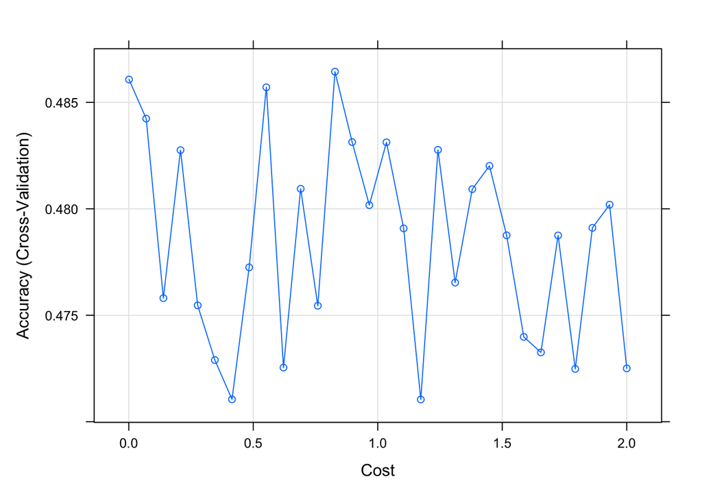

```r
#Visualize accuracy versus values of C
plot(model_svc)
```

```r
#Obtain metrics of accuracy from training
confusionMatrix(model_svc)
```

```
## Cross-Validated (10 fold) Confusion Matrix
##
## (entries are percentual average cell counts across resamples)
##
##           Reference
## Prediction    1    2    3
##          1 13.5 16.1  2.0
##          2  7.3 33.5  2.5
##          3  5.4 18.1  1.7
##
##  Accuracy (average) : 0.4865
```

```r
#See information about final model
model_svc$finalModel
```

```
## Support Vector Machine object of class "ksvm"
##
## SV type: C-svc  (classification)
##  parameter : cost C = 0.828172413793104
##
## Linear (vanilla) kernel function.
##
## Number of Support Vectors : 4879
##
## Objective Function Value : -2162.774 -2020.102 -2303.5
## Training error : 0.453218
```

```r
# varImp(model_svc)

svm_outcome <- predict(model_svc, df_district_train, type = "raw")
confusionMatrix(svm_outcome, df_district_train$q85)
```

```
## Confusion Matrix and Statistics
##
##           Reference
## Prediction   1   2   3
##          1 417 457  43
##          2 152 912  33
##          3 146 480  92
##
## Overall Statistics
##
##                Accuracy : 0.5201
##                  95% CI : (0.5012, 0.539)
##     No Information Rate : 0.6768
##     P-Value [Acc > NIR] : 1
##
##                   Kappa : 0.2313
##
##  Mcnemar's Test P-Value : <2e-16
##
## Statistics by Class:
##
##                      Class: 1 Class: 2 Class: 3
## Sensitivity            0.5832   0.4932  0.54762
## Specificity            0.7521   0.7905  0.75585
## Pos Pred Value         0.4547   0.8314  0.12813
## Neg Pred Value         0.8358   0.4269  0.96226
## Prevalence             0.2617   0.6768  0.06149
## Detection Rate         0.1526   0.3338  0.03367
## Detection Prevalence   0.3357   0.4015  0.26281
## Balanced Accuracy      0.6677   0.6419  0.65173
```

## fit the lasso regression

```r
set.seed(123)
#Create grid to search lambda
lambda <- 10^seq(-3,3, length = 100)

# Specify training control
train_control_lasso <- trainControl(method = "cv", number = 10)

model_lasso = train(q85 ~.,
                    df_district_train,
                    method = "glmnet",
                    trControl = train_control_lasso,
                    tuneGrid = expand.grid(alpha = 1, lambda = lambda))

summary(model_lasso)
```

```
##             Length Class      Mode
## a0          222    -none-     numeric
## beta          3    -none-     list
## dfmat       222    -none-     numeric
## df           74    -none-     numeric
## dim           2    -none-     numeric
## lambda       74    -none-     numeric
## dev.ratio    74    -none-     numeric
## nulldev       1    -none-     numeric
## npasses       1    -none-     numeric
## jerr          1    -none-     numeric
## offset        1    -none-     logical
## classnames    3    -none-     character
## grouped       1    -none-     logical
## call          5    -none-     call
## nobs          1    -none-     numeric
## lambdaOpt     1    -none-     numeric
## xNames       72    -none-     character
## problemType   1    -none-     character
## tuneValue     2    data.frame list
## obsLevels     3    -none-     character
## param         0    -none-     list
```

```r
model_lasso$bestTune
```

```
##    alpha      lambda
## 13     1 0.005336699
```

```r
model_lasso$results
```

```
##     alpha       lambda  Accuracy       Kappa  AccuracySD    KappaSD
## 1       1 1.000000e-03 0.7013218 0.207086564 0.020424308 0.05055149
## 2       1 1.149757e-03 0.7009555 0.205129506 0.022372280 0.05666194
## 3       1 1.321941e-03 0.7013191 0.203844562 0.023840276 0.06075774
## 4       1 1.519911e-03 0.7024140 0.205607202 0.023437436 0.06077622
## 5       1 1.747528e-03 0.7031507 0.205544645 0.022748148 0.05981987
## 6       1 2.009233e-03 0.7042482 0.208391784 0.022780278 0.05876049
## 7       1 2.310130e-03 0.7057121 0.210350892 0.021385153 0.05517474
## 8       1 2.656088e-03 0.7049835 0.206500809 0.021253666 0.05415051
## 9       1 3.053856e-03 0.7057135 0.206437440 0.020434415 0.05336442
## 10      1 3.511192e-03 0.7053498 0.204560892 0.020321850 0.05177413
## 11      1 4.037017e-03 0.7042536 0.198665904 0.019045462 0.04852716
## 12      1 4.641589e-03 0.7057135 0.199246242 0.019086890 0.05123422
## 13      1 5.336699e-03 0.7079113 0.200900724 0.019107361 0.05276923
## 14      1 6.135907e-03 0.7075450 0.195688495 0.022051255 0.05898746
```

[output cut: 86 more lines]

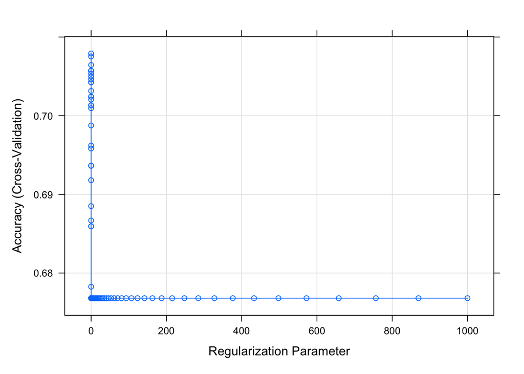

```r
#Visualize accuracy versus values of C
plot(model_lasso)
```

```r
#Obtain metrics of accuracy from training
confusionMatrix(model_lasso)
```

```
## Cross-Validated (10 fold) Confusion Matrix
##
## (entries are percentual average cell counts across resamples)
##
##           Reference
## Prediction    1    2    3
##          1  6.4  3.3  0.6
##          2 19.8 64.4  5.6
##          3  0.0  0.0  0.0
##
##  Accuracy (average) : 0.7079
```

```r
varImp(model_lasso)
```

```
## glmnet variable importance
##
##   variables are sorted by maximum importance across the classes
##   only 20 most important variables shown (out of 72)
##
##                                              1        2      3
## q177                                 1.000e+02  0.00000  0.000
## q178                                 2.974e-03 74.20730  0.000
## sitenamePhiladelphia, PA (PH)        5.939e+01 40.75312  0.000
## qnothhpl2                            3.738e+01 11.02728  0.000
## q174                                 3.674e+01  0.01355  0.000
## q653                                 3.537e+01  0.00000  0.000
## q215                                 0.000e+00 34.69153  0.000
## q214                                 6.840e+00 30.19547  0.000
## sitenamePortland, OR (PO)            2.829e+01  0.00000  0.000
## q532                                 0.000e+00 27.53211  0.000
## q654                                 2.714e+01  0.00000 24.257
## q895                                 0.000e+00 26.98799  0.000
## race42                               2.687e+01  7.13936  0.000
## q173                                 0.000e+00 23.31819  0.000
## q496                                 0.000e+00  0.00000 22.659
## q502                                 2.033e+01  0.00000  2.658
## q492                                 1.948e+01  0.00000  0.000
## sitenameHillsborough County, FL (HL) 1.945e+01 11.36996  0.000
## sitenameSan Francisco, CA (SF)       1.501e+01 19.01483  0.000
## age6                                 1.793e+01  0.00000  0.000
```

```r
lasso_outcome <- predict(model_lasso, df_district_train, type = "raw")
confusionMatrix(lasso_outcome, df_district_train$q85)
```

```
## Confusion Matrix and Statistics
##
##           Reference
## Prediction    1    2    3
##          1  184   75   16
##          2  531 1774  152
##          3    0    0    0
##
## Overall Statistics
##
##                Accuracy : 0.7167
##                  95% CI : (0.6994, 0.7335)
##     No Information Rate : 0.6768
##     P-Value [Acc > NIR] : 3.604e-06
##
##                   Kappa : 0.2238
##
##  Mcnemar's Test P-Value : < 2.2e-16
##
## Statistics by Class:
##
##                      Class: 1 Class: 2 Class: 3
## Sensitivity           0.25734   0.9594  0.00000
## Specificity           0.95488   0.2265  1.00000
## Pos Pred Value        0.66909   0.7220      NaN
## Neg Pred Value        0.78388   0.7273  0.93851
## Prevalence            0.26171   0.6768  0.06149
## Detection Rate        0.06735   0.6493  0.00000
## Detection Prevalence  0.10066   0.8993  0.00000
## Balanced Accuracy     0.60611   0.5930  0.50000
```

## fit the ridge regression

```r
set.seed(123)
#Create grid to search lambda
lambda <- 10^seq(-3,3, length = 100)

# Specify training control
train_control_ridge <- trainControl(method = "cv", number = 10)

model_ridge = train(q85 ~.,
                    df_district_train,
                    method = "glmnet",
                    trControl = train_control_ridge,
                    tuneGrid = expand.grid(alpha = 0, lambda = lambda))

summary(model_ridge)
```

```
##             Length Class      Mode
## a0          300    -none-     numeric
## beta          3    -none-     list
## dfmat       300    -none-     numeric
## df          100    -none-     numeric
## dim           2    -none-     numeric
## lambda      100    -none-     numeric
## dev.ratio   100    -none-     numeric
## nulldev       1    -none-     numeric
## npasses       1    -none-     numeric
## jerr          1    -none-     numeric
## offset        1    -none-     logical
## classnames    3    -none-     character
## grouped       1    -none-     logical
## call          5    -none-     call
## nobs          1    -none-     numeric
## lambdaOpt     1    -none-     numeric
## xNames       72    -none-     character
## problemType   1    -none-     character
## tuneValue     2    data.frame list
## obsLevels     3    -none-     character
## param         0    -none-     list
```

```r
model_ridge$bestTune
```

```
##    alpha     lambda
## 30     0 0.05722368
```

```r
model_ridge$results
```

```
##     alpha       lambda  Accuracy       Kappa  AccuracySD     KappaSD
## 1       0 1.000000e-03 0.7027857 0.213465792 0.019732173 0.049603435
## 2       0 1.149757e-03 0.7027857 0.213465792 0.019732173 0.049603435
## 3       0 1.321941e-03 0.7027857 0.213465792 0.019732173 0.049603435
## 4       0 1.519911e-03 0.7027857 0.213465792 0.019732173 0.049603435
## 5       0 1.747528e-03 0.7027857 0.213465792 0.019732173 0.049603435
## 6       0 2.009233e-03 0.7027857 0.213465792 0.019732173 0.049603435
## 7       0 2.310130e-03 0.7027857 0.213465792 0.019732173 0.049603435
## 8       0 2.656088e-03 0.7027857 0.213465792 0.019732173 0.049603435
## 9       0 3.053856e-03 0.7027857 0.213465792 0.019732173 0.049603435
## 10      0 3.511192e-03 0.7027857 0.213465792 0.019732173 0.049603435
## 11      0 4.037017e-03 0.7027857 0.213465792 0.019732173 0.049603435
## 12      0 4.641589e-03 0.7027857 0.213465792 0.019732173 0.049603435
## 13      0 5.336699e-03 0.7027857 0.213465792 0.019732173 0.049603435
## 14      0 6.135907e-03 0.7027857 0.213465792 0.019732173 0.049603435
```

[output cut: 86 more lines]

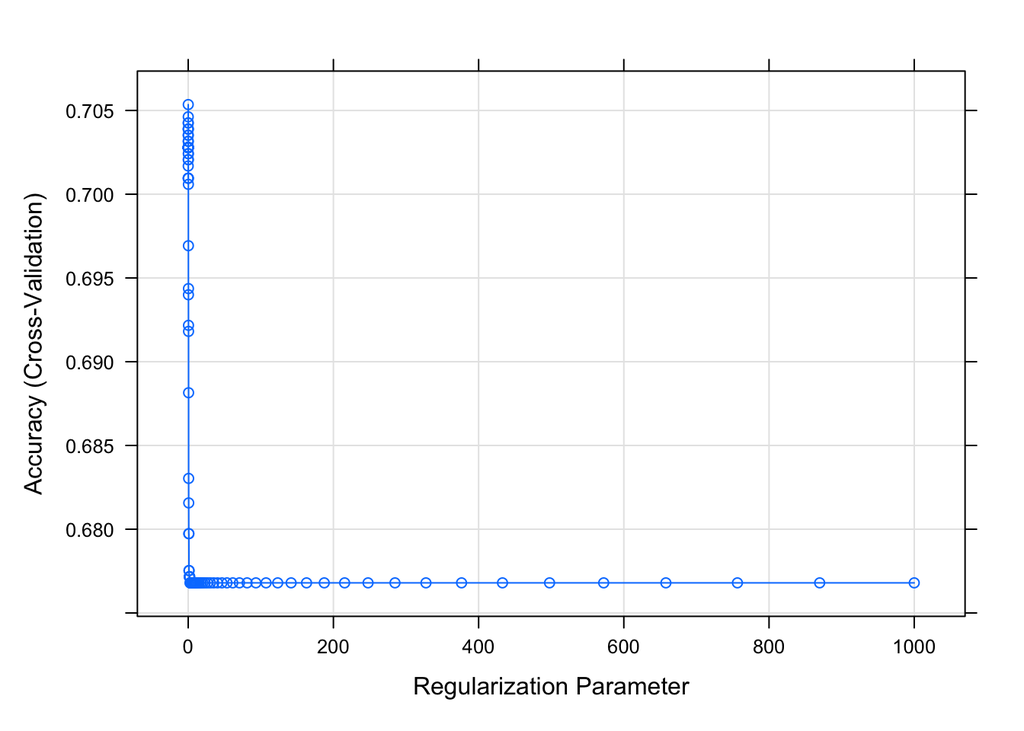

```r
#Visualize accuracy versus values of C
plot(model_ridge)
```

```r
#Obtain metrics of accuracy from training
confusionMatrix(model_ridge)
```

```
## Cross-Validated (10 fold) Confusion Matrix
##
## (entries are percentual average cell counts across resamples)
##
##           Reference
## Prediction    1    2    3
##          1  6.6  3.7  0.7
##          2 19.6 64.0  5.5
##          3  0.0  0.0  0.0
##
##  Accuracy (average) : 0.7053
```

```r
varImp(model_ridge)
```

```
## glmnet variable importance
##
##   variables are sorted by maximum importance across the classes
##   only 20 most important variables shown (out of 72)
##
##                                            1       2      3
## q177                                 100.000 53.5475 46.379
## q178                                  40.773 66.0377 25.192
## sitenamePhiladelphia, PA (PH)         62.832 56.8545  5.904
## q215                                  13.107 51.8628 38.683
## q416                                  18.376 33.2761 51.726
## q532                                  18.461 43.6776 25.144
## q522                                   6.403 33.4841 39.960
## q417                                  30.370  4.7378 35.181
## q214                                  23.305 34.2848 10.907
## q174                                  34.169 22.5160 11.580
## qnothhpl2                             32.436 26.5854  5.777
## q496                                  14.891 14.8940 29.858
## q895                                  12.840 29.7919 16.879
## sitenameHillsborough County, FL (HL)  28.400 23.6719  4.655
## q873                                  11.759 15.4622 27.294
## q654                                  27.211  0.3648 26.773
## race42                                26.409 19.8838  6.452
## q175                                  19.460  4.3333 23.867
## sitenamePortland, OR (PO)             22.951  9.7916 13.086
## q653                                  22.525 16.7805  5.672
```

```r
ridge_outcome <- predict(model_ridge, df_district_train, type = "raw")
confusionMatrix(ridge_outcome, df_district_train$q85)
```

```
## Confusion Matrix and Statistics
##
##           Reference
## Prediction    1    2    3
##          1  192   85   18
##          2  523 1764  150
##          3    0    0    0
##
## Overall Statistics
##
##                Accuracy : 0.716
##                  95% CI : (0.6986, 0.7328)
##     No Information Rate : 0.6768
##     P-Value [Acc > NIR] : 5.322e-06
##
##                   Kappa : 0.2282
##
##  Mcnemar's Test P-Value : < 2.2e-16
##
## Statistics by Class:
##
##                      Class: 1 Class: 2 Class: 3
## Sensitivity           0.26853   0.9540  0.00000
## Specificity           0.94893   0.2378  1.00000
## Pos Pred Value        0.65085   0.7238      NaN
## Neg Pred Value        0.78539   0.7119  0.93851
## Prevalence            0.26171   0.6768  0.06149
## Detection Rate        0.07028   0.6457  0.00000
## Detection Prevalence  0.10798   0.8920  0.00000
## Balanced Accuracy     0.60873   0.5959  0.50000
```

## fit the Elastic Net method

```r
# model 2, chooses alpha and lambda via cross-validation using all of the features - Elastic Net method
set.seed(123)

# Construct k-folds in your data
trcontrol = trainControl(method = "cv", number = 10, sampling = "up")

# model 2 fit
model_elastic_net <- train(q85 ~.,
                     data = df_district_train,
                     method = "glmnet",
                     trControl = trcontrol,
                     preProc=c("center", "scale"),
                     tuneLength = 10, metric = "Accuracy"
  )

# Print the values of alpha and lambda that gave best prediction
model_elastic_net$bestTune
```

```
##     alpha     lambda
## 100     1 0.07565328
```

```r
# Print all of the options examined
model_elastic_net$results
```

```
##     alpha       lambda  Accuracy     Kappa AccuracySD    KappaSD
## 1     0.1 4.037388e-05 0.4875323 0.1543854 0.03308829 0.03645356
## 2     0.1 9.326890e-05 0.4875323 0.1543854 0.03308829 0.03645356
## 3     0.1 2.154633e-04 0.4875323 0.1543854 0.03308829 0.03645356
## 4     0.1 4.977481e-04 0.4875323 0.1543854 0.03308829 0.03645356
## 5     0.1 1.149863e-03 0.4867997 0.1509165 0.03291185 0.03807165
## 6     0.1 2.656332e-03 0.4875215 0.1542778 0.03535356 0.04226261
## 7     0.1 6.136471e-03 0.4900937 0.1586698 0.02954324 0.03630087
## 8     0.1 1.417604e-02 0.4886379 0.1593910 0.03518547 0.04292788
## 9     0.1 3.274850e-02 0.4919252 0.1672350 0.03397752 0.04481133
## 10    0.1 7.565328e-02 0.4864240 0.1582993 0.03617406 0.04569978
## 11    0.2 4.037388e-05 0.4889586 0.1630425 0.03903883 0.04280597
## 12    0.2 9.326890e-05 0.4889586 0.1630425 0.03903883 0.04280597
## 13    0.2 2.154633e-04 0.4889586 0.1630425 0.03903883 0.04280597
## 14    0.2 4.977481e-04 0.4885937 0.1628225 0.03859750 0.04247745
```

[output cut: 86 more lines]

```r
# Model coefficients
coef(model_elastic_net$finalModel, model_elastic_net$bestTune$lambda)
```

```
## $`1`
## 73 x 1 sparse Matrix of class "dgCMatrix"
##                                                  1
## (Intercept)                          -0.0001045423
## sitenameChicago, IL (CH)              .
## sitenameEaton Consortium, MI (EA)     .
## sitenameFort Worth, TX (FW)           .
## sitenameGenesee Consortium, MI (GE)   .
## sitenameHillsborough County, FL (HL)  .
## sitenameLos Angeles, CA (LO)          .
## sitenameNewark, NJ (NW)               .
## sitenameOrange County, FL (OL)        .
## sitenamePalm Beach County, FL (PB)    .
## sitenamePasco County, FL (PS)         .
## sitenamePhiladelphia, PA (PH)         0.0045062989
## sitenamePortland, OR (PO)             .
## sitenameSan Francisco, CA (SF)        .
## sitenameShelby County, TN (ST)        .
## age4                                  .
## age5                                  .
## age6                                  .
## age7                                  .
## sex2                                  .
## grade2                                .
## grade3                                .
## grade4                                .
## race42                                .
## race43                                .
## race44                                .
## bmi                                   .
## qnothhpl2                            -0.0272980017
## q172                                  .
## q173                                  .
## q174                                  .
## q175                                  .
## q176                                  .
## q177                                  .
## q178                                  .
## q212                                  .
## q213                                  .
```

[output cut: 175 more lines]

```
## q496                                 .
## q502                                 .
## q522                                 .
## q532                                 .
## q633                                 .
## q653                                 .
## q654                                 .
## q872                                 .
## q873                                 .
## q892                                 .
## q893                                 .
## q894                                 .
## q895                                 .
## q896                                 .
## q897                                 .
```

```r
# visualization and accuracy
varImp(model_elastic_net)
```

```
## glmnet variable importance
##
##   variables are sorted by maximum importance across the classes
##   only 20 most important variables shown (out of 72)
##
##                                           1 2 3
## qnothhpl2                            100.00 0 0
## sitenamePhiladelphia, PA (PH)         16.51 0 0
## q653                                   0.00 0 0
## q216                                   0.00 0 0
## sitenameHillsborough County, FL (HL)   0.00 0 0
## sitenamePasco County, FL (PS)          0.00 0 0
## q872                                   0.00 0 0
## q212                                   0.00 0 0
## q414                                   0.00 0 0
## q415                                   0.00 0 0
## q894                                   0.00 0 0
## age7                                   0.00 0 0
## race42                                 0.00 0 0
## q492                                   0.00 0 0
## q417                                   0.00 0 0
## q215                                   0.00 0 0
## q473                                   0.00 0 0
## q232                                   0.00 0 0
## race43                                 0.00 0 0
## sitenameLos Angeles, CA (LO)           0.00 0 0
```

[figure not shown]

```r
plot(varImp(model_elastic_net))
```

```r
confusionMatrix(model_elastic_net)
```

```
## Cross-Validated (10 fold) Confusion Matrix
##
## (entries are percentual average cell counts across resamples)
##
##           Reference
## Prediction    1    2    3
##          1 10.1 11.7  1.6
##          2 16.1 56.0  4.5
##          3  0.0  0.0  0.0
##
##  Accuracy (average) : 0.6603
```

```r
elastic_net_outcome <- predict(model_elastic_net, df_district_train, type = "raw")
confusionMatrix(elastic_net_outcome, df_district_train$q85)
```

```
## Confusion Matrix and Statistics
##
##           Reference
## Prediction    1    2    3
##          1  286  407   42
##          2  429 1442  126
##          3    0    0    0
##
## Overall Statistics
##
##                Accuracy : 0.6325
##                  95% CI : (0.6141, 0.6506)
##     No Information Rate : 0.6768
##     P-Value [Acc > NIR] : 1
##
##                   Kappa : 0.1549
##
##  Mcnemar's Test P-Value : <2e-16
##
## Statistics by Class:
##
##                      Class: 1 Class: 2 Class: 3
## Sensitivity            0.4000   0.7799  0.00000
## Specificity            0.7774   0.3715  1.00000
## Pos Pred Value         0.3891   0.7221      NaN
## Neg Pred Value         0.7852   0.4463  0.93851
## Prevalence             0.2617   0.6768  0.06149
## Detection Rate         0.1047   0.5278  0.00000
## Detection Prevalence   0.2690   0.7310  0.00000
## Balanced Accuracy      0.5887   0.5757  0.50000
```

## fit the classfication Tree model

```r
set.seed(123)

#Using 10-fold cross-validation to train model
train_control_tree <- trainControl(method = "cv", number = 10, sampling = "up")

#Create sequence of cp parameters to try
grid_tree <- expand.grid(cp = seq(0.001, 0.3, by = 0.01))

#Using rpart method to generate regression tree, using all variables in dataset to predict life expectancy
model_tree <- train(q85 ~ . ,
                     data = df_district_train,
                     method = "rpart",
                     trControl = train_control_tree,
                     tuneGrid = grid_tree)

model_tree$bestTune
```

```
##      cp
## 6 0.051
```

```r
model_tree$results
```

```
##       cp  Accuracy       Kappa  AccuracySD    KappaSD
## 1  0.001 0.4828038 0.090021607 0.029766619 0.05871077
## 2  0.011 0.4834665 0.129749161 0.077497944 0.04728868
## 3  0.021 0.5205195 0.143741020 0.110503421 0.06628778
## 4  0.031 0.5613174 0.172176485 0.149037050 0.07792167
## 5  0.041 0.5880279 0.163441459 0.140715947 0.07117927
## 6  0.051 0.5880279 0.163441459 0.140715947 0.07117927
## 7  0.061 0.5130767 0.121647049 0.191644075 0.09170329
## 8  0.071 0.3997539 0.062779120 0.196204424 0.08604528
## 9  0.081 0.3997539 0.062779120 0.196204424 0.08604528
## 10 0.091 0.3245714 0.024124644 0.153906491 0.05269571
## 11 0.101 0.2938291 0.004617076 0.101947908 0.01460048
## 12 0.111 0.2617123 0.000000000 0.001655971 0.00000000
## 13 0.121 0.2617123 0.000000000 0.001655971 0.00000000
## 14 0.131 0.2617123 0.000000000 0.001655971 0.00000000
```

[output cut: 16 more lines]

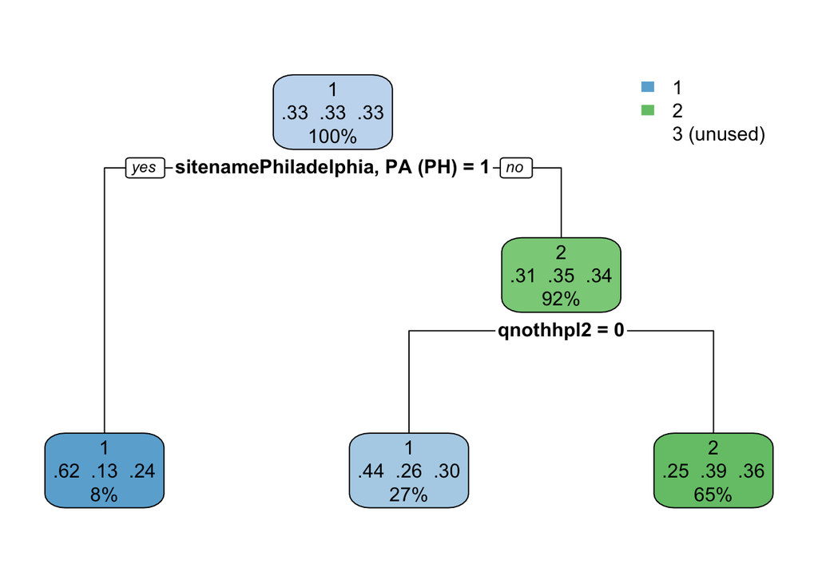

```r
#Can use rpart.plot function to visualize tree
rpart.plot(model_tree$finalModel)
```

```r
#Note you can obtain variable importance on the final model within training data
varImp(model_tree)
```

```
## rpart variable importance
##
##   only 20 most important variables shown (out of 73)
##
##                                  Overall
## qnothhpl2                         100.00
## sex2                               80.74
## sitenamePhiladelphia, PA (PH)      54.30
## q653                               44.08
## q633                               42.89
## q654                               17.23
## age7                                0.00
## q494                                0.00
## q897                                0.00
## q302                                0.00
## grade3                              0.00
## `sitenameOrange County, FL (OL)`    0.00
## q232                                0.00
## q475                                0.00
## grade2                              0.00
## q894                                0.00
## q214                                0.00
## q522                                0.00
## `sitenamePhiladelphia, PA (PH)`     0.00
## age4                                0.00
```

```r
tree_outcome <- predict(model_tree, df_district_train, type = "raw")
confusionMatrix(tree_outcome, df_district_train$q85)
```

```
## Confusion Matrix and Statistics
##
##           Reference
## Prediction    1    2    3
##          1  354  458   51
##          2  361 1391  117
##          3    0    0    0
##
## Overall Statistics
##
##                Accuracy : 0.6387
##                  95% CI : (0.6204, 0.6568)
##     No Information Rate : 0.6768
##     P-Value [Acc > NIR] : 1
##
##                   Kappa : 0.2048
##
##  Mcnemar's Test P-Value : <2e-16
##
## Statistics by Class:
##
##                      Class: 1 Class: 2 Class: 3
## Sensitivity            0.4951   0.7523  0.00000
## Specificity            0.7476   0.4587  1.00000
## Pos Pred Value         0.4102   0.7442      NaN
## Neg Pred Value         0.8068   0.4693  0.93851
## Prevalence             0.2617   0.6768  0.06149
## Detection Rate         0.1296   0.5092  0.00000
## Detection Prevalence   0.3159   0.6841  0.00000
## Balanced Accuracy      0.6214   0.6055  0.50000
```

# Step 4, evaluation and best model selection - multinominal logistic regression, random forest, SVM, classfication Tree, Elastic Net, ridge, lasso regression, and classification tree

```r
# model multinominal logistic regression
multinom_outcome <- predict(model_multinom, df_district_train, type = "raw")
multinom_evaluation <- confusionMatrix(multinom_outcome, df_district_train$q85, positive = "1")
multinom_evaluation
```

```
## Confusion Matrix and Statistics
##
##           Reference
## Prediction   1   2   3
##          1 396 413  45
##          2 162 968  39
##          3 157 468  84
##
## Overall Statistics
##
##                Accuracy : 0.53
##                  95% CI : (0.5111, 0.5489)
##     No Information Rate : 0.6768
##     P-Value [Acc > NIR] : 1
##
##                   Kappa : 0.2328
##
##  Mcnemar's Test P-Value : <2e-16
##
## Statistics by Class:
##
##                      Class: 1 Class: 2 Class: 3
## Sensitivity            0.5538   0.5235  0.50000
## Specificity            0.7729   0.7724  0.75624
## Pos Pred Value         0.4637   0.8281  0.11848
## Neg Pred Value         0.8301   0.4363  0.95848
## Prevalence             0.2617   0.6768  0.06149
## Detection Rate         0.1449   0.3543  0.03075
## Detection Prevalence   0.3126   0.4279  0.25952
## Balanced Accuracy      0.6634   0.6479  0.62812
```

```r
# model random forest
rf_outcome <- predict(model_rf, df_district_train, type = "raw")
rf_evaluation <- confusionMatrix(rf_outcome, df_district_train$q85, positive = "1")
rf_evaluation
```

```
## Confusion Matrix and Statistics
##
##           Reference
## Prediction    1    2    3
##          1  715    0    0
##          2    0 1848    0
##          3    0    1  168
##
## Overall Statistics
##
##                Accuracy : 0.9996
##                  95% CI : (0.998, 1)
##     No Information Rate : 0.6768
##     P-Value [Acc > NIR] : < 2.2e-16
##
##                   Kappa : 0.9992
##
##  Mcnemar's Test P-Value : NA
##
## Statistics by Class:
##
##                      Class: 1 Class: 2 Class: 3
## Sensitivity            1.0000   0.9995  1.00000
## Specificity            1.0000   1.0000  0.99961
## Pos Pred Value         1.0000   1.0000  0.99408
## Neg Pred Value         1.0000   0.9989  1.00000
## Prevalence             0.2617   0.6768  0.06149
## Detection Rate         0.2617   0.6764  0.06149
## Detection Prevalence   0.2617   0.6764  0.06186
## Balanced Accuracy      1.0000   0.9997  0.99980
```

```r
# model SVM
svm_outcome <- predict(model_svc, df_district_train, type = "raw")
svm_evaluation <- confusionMatrix(svm_outcome, df_district_train$q85, positive = "1")
svm_evaluation
```

```
## Confusion Matrix and Statistics
##
##           Reference
## Prediction   1   2   3
##          1 417 457  43
##          2 152 912  33
##          3 146 480  92
##
## Overall Statistics
##
##                Accuracy : 0.5201
##                  95% CI : (0.5012, 0.539)
##     No Information Rate : 0.6768
##     P-Value [Acc > NIR] : 1
##
##                   Kappa : 0.2313
##
##  Mcnemar's Test P-Value : <2e-16
##
## Statistics by Class:
##
##                      Class: 1 Class: 2 Class: 3
## Sensitivity            0.5832   0.4932  0.54762
## Specificity            0.7521   0.7905  0.75585
## Pos Pred Value         0.4547   0.8314  0.12813
## Neg Pred Value         0.8358   0.4269  0.96226
## Prevalence             0.2617   0.6768  0.06149
## Detection Rate         0.1526   0.3338  0.03367
## Detection Prevalence   0.3357   0.4015  0.26281
## Balanced Accuracy      0.6677   0.6419  0.65173
```

```r
# model lasso
lasso_outcome <- predict(model_lasso, df_district_train, type = "raw")
lasso_evaluation <- confusionMatrix(lasso_outcome, df_district_train$q85, positive = "1")
lasso_evaluation
```

```
## Confusion Matrix and Statistics
##
##           Reference
## Prediction    1    2    3
##          1  184   75   16
##          2  531 1774  152
##          3    0    0    0
##
## Overall Statistics
##
##                Accuracy : 0.7167
##                  95% CI : (0.6994, 0.7335)
##     No Information Rate : 0.6768
##     P-Value [Acc > NIR] : 3.604e-06
##
##                   Kappa : 0.2238
##
##  Mcnemar's Test P-Value : < 2.2e-16
##
## Statistics by Class:
##
##                      Class: 1 Class: 2 Class: 3
## Sensitivity           0.25734   0.9594  0.00000
## Specificity           0.95488   0.2265  1.00000
## Pos Pred Value        0.66909   0.7220      NaN
## Neg Pred Value        0.78388   0.7273  0.93851
## Prevalence            0.26171   0.6768  0.06149
## Detection Rate        0.06735   0.6493  0.00000
## Detection Prevalence  0.10066   0.8993  0.00000
## Balanced Accuracy     0.60611   0.5930  0.50000
```

```r
# model ridge
ridge_outcome <- predict(model_ridge, df_district_train, type = "raw")
ridge_evaluation <- confusionMatrix(ridge_outcome, df_district_train$q85, positive = "1")
ridge_evaluation
```

```
## Confusion Matrix and Statistics
##
##           Reference
## Prediction    1    2    3
##          1  192   85   18
##          2  523 1764  150
##          3    0    0    0
##
## Overall Statistics
##
##                Accuracy : 0.716
##                  95% CI : (0.6986, 0.7328)
##     No Information Rate : 0.6768
##     P-Value [Acc > NIR] : 5.322e-06
##
##                   Kappa : 0.2282
##
##  Mcnemar's Test P-Value : < 2.2e-16
##
## Statistics by Class:
##
##                      Class: 1 Class: 2 Class: 3
## Sensitivity           0.26853   0.9540  0.00000
## Specificity           0.94893   0.2378  1.00000
## Pos Pred Value        0.65085   0.7238      NaN
## Neg Pred Value        0.78539   0.7119  0.93851
## Prevalence            0.26171   0.6768  0.06149
## Detection Rate        0.07028   0.6457  0.00000
## Detection Prevalence  0.10798   0.8920  0.00000
## Balanced Accuracy     0.60873   0.5959  0.50000
```

```r
# model elastic net
elastic_net_outcome <- predict(model_elastic_net, df_district_train, type = "raw")
elastic_net_evaluation <- confusionMatrix(elastic_net_outcome, df_district_train$q85, positive = "1")
elastic_net_evaluation
```

```
## Confusion Matrix and Statistics
##
##           Reference
## Prediction    1    2    3
##          1  286  407   42
##          2  429 1442  126
##          3    0    0    0
##
## Overall Statistics
##
##                Accuracy : 0.6325
##                  95% CI : (0.6141, 0.6506)
##     No Information Rate : 0.6768
##     P-Value [Acc > NIR] : 1
##
##                   Kappa : 0.1549
##
##  Mcnemar's Test P-Value : <2e-16
##
## Statistics by Class:
##
##                      Class: 1 Class: 2 Class: 3
## Sensitivity            0.4000   0.7799  0.00000
## Specificity            0.7774   0.3715  1.00000
## Pos Pred Value         0.3891   0.7221      NaN
## Neg Pred Value         0.7852   0.4463  0.93851
## Prevalence             0.2617   0.6768  0.06149
## Detection Rate         0.1047   0.5278  0.00000
## Detection Prevalence   0.2690   0.7310  0.00000
## Balanced Accuracy      0.5887   0.5757  0.50000
```

```r
# model classification tree
tree_outcome <- predict(model_tree, df_district_train, type = "raw")
tree_evaluation <- confusionMatrix(tree_outcome, df_district_train$q85, positive = "1")
tree_evaluation
```

```
## Confusion Matrix and Statistics
##
##           Reference
## Prediction    1    2    3
##          1  354  458   51
##          2  361 1391  117
##          3    0    0    0
##
## Overall Statistics
##
##                Accuracy : 0.6387
##                  95% CI : (0.6204, 0.6568)
##     No Information Rate : 0.6768
##     P-Value [Acc > NIR] : 1
##
##                   Kappa : 0.2048
##
##  Mcnemar's Test P-Value : <2e-16
##
## Statistics by Class:
##
##                      Class: 1 Class: 2 Class: 3
## Sensitivity            0.4951   0.7523  0.00000
## Specificity            0.7476   0.4587  1.00000
## Pos Pred Value         0.4102   0.7442      NaN
## Neg Pred Value         0.8068   0.4693  0.93851
## Prevalence             0.2617   0.6768  0.06149
## Detection Rate         0.1296   0.5092  0.00000
## Detection Prevalence   0.3159   0.6841  0.00000
## Balanced Accuracy      0.6214   0.6055  0.50000
```

```r
# Accuracy and 95% CI plot
compare_resamp <- resamples(list(
  multinom = model_multinom,
  random_forest = model_rf,
  SVM = model_svc,
  lasso = model_lasso,
  ridge = model_ridge,
  elastic_net = model_elastic_net,
  cla_tree = model_tree
))

summary(compare_resamp)
```

```
##
## Call:
## summary.resamples(object = compare_resamp)
##
## Models: multinom, random_forest, SVM, lasso, ridge, elastic_net, cla_tree
## Number of resamples: 10
##
## Accuracy
##                    Min.   1st Qu.    Median      Mean   3rd Qu.      Max. NA's
## multinom      0.4485294 0.4638546 0.5119115 0.4984932 0.5233316 0.5401460    0
## random_forest 0.6496350 0.6666667 0.6782372 0.6767917 0.6865809 0.7043796    0
## SVM           0.4358974 0.4655583 0.4890110 0.4864415 0.5119619 0.5328467    0
## lasso         0.6788321 0.7013716 0.7098540 0.7079113 0.7162553 0.7435897    0
## ridge         0.6764706 0.6931599 0.7062044 0.7053525 0.7153395 0.7472527    0
## elastic_net   0.5802920 0.6432482 0.6544745 0.6603911 0.6933009 0.7142857    0
## cla_tree      0.1911765 0.6272894 0.6318699 0.5880279 0.6447455 0.6520147    0
##
## Kappa
##                     Min.   1st Qu.    Median      Mean   3rd Qu.      Max. NA's
## multinom      0.10673235 0.1486336 0.1710276 0.1731134 0.2011490 0.2226600    0
## random_forest 0.14033597 0.1711848 0.1871057 0.1948232 0.2138996 0.2878093    0
## SVM           0.10407876 0.1384598 0.1630538 0.1581660 0.1751599 0.2035245    0
## lasso         0.09981741 0.1859858 0.2009429 0.2009007 0.2260962 0.2978395    0
## ridge         0.09716355 0.1746027 0.2057442 0.2002764 0.2193305 0.3107574    0
## elastic_net   0.07784931 0.1350984 0.2071040 0.1872170 0.2370896 0.2944334    0
## cla_tree      0.02806653 0.1685574 0.1783251 0.1634415 0.2026587 0.2383436    0
```

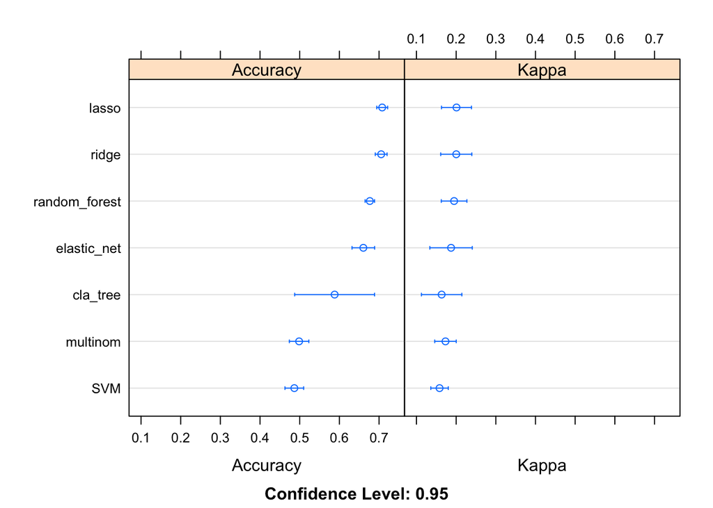

```r
dotplot(compare_resamp)
```

```r
# create table of accuracy and kappa
postResample(multinom_outcome, df_district_train$q85)
```

```
##  Accuracy     Kappa
## 0.5300146 0.2328496
```

```r
postResample(rf_outcome, df_district_train$q85)
```

```
## Accuracy    Kappa
## 0.999634 0.999221
```

```r
postResample(svm_outcome, df_district_train$q85)
```

```
##  Accuracy     Kappa
## 0.5201318 0.2312719
```

```r
postResample(lasso_outcome, df_district_train$q85)
```

```
##  Accuracy     Kappa
## 0.7166911 0.2237856
```

```r
postResample(ridge_outcome, df_district_train$q85)
```

```
##  Accuracy     Kappa
## 0.7159590 0.2282053
```

```r
postResample(elastic_net_outcome, df_district_train$q85)
```

```
##  Accuracy     Kappa
## 0.6325037 0.1549420
```

```r
postResample(tree_outcome, df_district_train$q85)
```

```
##  Accuracy     Kappa
## 0.6387262 0.2048111
```